# R Notebook

[output not shown]

# Herbarium data

from: Meineke EK, Classen AT, Sanders NJ, Jonathan Davies T (2018) Herbarium specimens reveal increasing herbivory over the past century. J Ecol 1–13. doi: 10.1111/1365-2745.13057

| decade | state | herbivory | specimens |
| --- | --- | --- | --- |
| 1930 | Maine | 12 | 15 |
| 1930 | Massachusetts | 17 | 26 |
| 1930 | New Hampshire | 17 | 20 |
| 1940 | Maine | 2 | 7 |
| 1940 | Massachusetts | 14 | 19 |
| 1940 | New Hampshire | 16 | 21 |
| 1950 | Maine | 0 | 3 |
| 1950 | Massachusetts | 6 | 12 |
| 1950 | New Hampshire | 8 | 16 |
| 1960 | Maine | 2 | 4 |

[output cut: 2 more lines]

```
(Intercept)
  0.6625767
```

```
as.factor(decade)1930 as.factor(decade)1940 as.factor(decade)1950 as.factor(decade)1960
            0.7540984             0.6808511             0.4516129             0.6666667
```

```
                          2.5 %    97.5 %
as.factor(decade)1930 0.6369965 0.8502878
as.factor(decade)1940 0.5404732 0.8020109
as.factor(decade)1950 0.2855402 0.6253863
as.factor(decade)1960 0.4680226 0.8314427
```

```
        stateMaine stateMassachusetts stateNew Hampshire
         0.5517241          0.6769231          0.6956522
```

```
                       2.5 %    97.5 %
stateMaine         0.3721306 0.7225402
stateMassachusetts 0.5579452 0.7822149
stateNew Hampshire 0.5813210 0.7957116
```

## Simple gall parasitism data

| size | successes | failures |
| --- | --- | --- |
| <12.5 | 13 | 2 |
| 13.0-17.5 | 9 | 3 |
| >18.0 | 1 | 15 |

```
(Intercept)
  0.5348837
```

```
    size<12.5     size>18.0 size13.0-17.5
    0.8666667     0.0625000     0.7500000
Likelihood ratio test

Model 1: cbind(successes, failures) ~ 1
Model 2: cbind(successes, failures) ~ -1 + size
  #Df   LogLik Df  Chisq Pr(>Chisq)
1   1 -16.8804
2   3  -3.5586  2 26.644  1.638e-06 ***
---
Signif. codes:  0 ‘***’ 0.001 ‘**’ 0.01 ‘*’ 0.05 ‘.’ 0.1 ‘ ’ 1
```

```
                    2.5 %    97.5 %
size<12.5     0.642352007 0.9765105
size>18.0     0.003673243 0.2474233
size13.0-17.5 0.472324456 0.9311378
```

# Gabby’s branch dieback data

1. Use a LRT to test if the proportion of dieback has a linear relationship to average fruit production in the previous year. Report and justify your conclusion.

```
Likelihood ratio test

Model 1: cbind(dieback, alive) ~ jun_frt
Model 2: cbind(dieback, alive) ~ 1
  #Df  LogLik Df  Chisq Pr(>Chisq)
1   2 -44.584
2   1 -44.621 -1 0.0735     0.7863
Likelihood ratio test

Model 1: cbind(dieback, alive) ~ -1 + farmer
Model 2: cbind(dieback, alive) ~ 1
  #Df  LogLik Df  Chisq Pr(>Chisq)
1   3 -35.312
2   1 -44.621 -2 18.617  9.064e-05 ***
---
Signif. codes:  0 ‘***’ 0.001 ‘**’ 0.01 ‘*’ 0.05 ‘.’ 0.1 ‘ ’ 1
```

```
                    2.5 %    97.5 %
farmerFernando 0.09238725 0.1651852
farmerMiguel   0.11527276 0.1904603
farmerOscar    0.20629691 0.3067765
         dAIC df
m_farmer  0.0 3
m0       14.6 1
m_frt    16.5 2
```

|  | df | AIC |
| --- | --- | --- |
| m0 | 1 | 91.24108 |
| m_frt | 2 | 93.16761 |
| m_farmer | 3 | 76.62377 |

2. An alternate hypothesis to explain these data is that branch dieback depends mostly on farmer practices. Use AIC to compare a null model (one dieback proportion), the model you fit in part a, and a model that estimates a different dieback proportion for each farmer. Report the AIC for each model, state and justify your conclusions.
3. If these coffee farms were randomly sampled from all the coffee farms in Costa Rica, and the coffee plants were randomly sampled within each farm, what would the scope of inference be for this experiment?

# Nick’s bees

In early spring, when floral resources can be scarce and unpredictable, queen bumble bees emerge from hibernation and start colonies underground. To understand how nutrition and body size jointly affect the probability of establishment, I caught wild queens (Bombus impatiens) and measured their body size, maintained them in lab conditions with either a high or low food treatment, and recorded whether or not they started a colony.

| ITS | Success | Food | BroodDay | DevDay | WorkNum |
| --- | --- | --- | --- | --- | --- |
| 7.71 | 0 | High | NA | NA | NA |
| 6.54 | 0 | High | 9 | NA | NA |
| 6.69 | 0 | High | 9 | NA | NA |
| 6.67 | 0 | High | NA | NA | NA |
| 6.16 | 0 | High | 8 | NA | NA |
| 6.37 | 0 | High | NA | NA | NA |
| 6.62 | 0 | High | 24 | NA | NA |
| 7.58 | 0 | High | NA | NA | NA |
| 6.66 | 0 | High | NA | NA | NA |
| 6.60 | 1 | High | 24 | 21 | 8 |

[output cut: 54 more lines]

# Western Monarch Thanksgiving Count

West of the Rocky Mountains, Monarch butterflies migrate to the California coast to overwinter. The Xerces Society leads a citizen science effort to monitor the abundance of Monarchs in the west by having volunteers count Monarchs at overwintering sites over Thanksgiving weekend. The population declined from 1.2 million in 1997 to only about 59,000 in 2009. From 2010 to 2016 the population appears to have increased, however the number of sites monitored also increased.

1. Write the glm() code you would use to model a change in the number of monarch butterflies per site over time using an offset to take into account differences in sampling effort for each year.

```
Analysis of Deviance Table (Type II tests)

Response: count_total
     LR Chisq Df Pr(>Chisq)
year    78729  1  < 2.2e-16 ***
---
Signif. codes:  0 ‘***’ 0.001 ‘**’ 0.01 ‘*’ 0.05 ‘.’ 0.1 ‘ ’ 1
(Intercept)        year
-216.565329    0.113684
[1] 199665.8
(Intercept)        year
38.95246820 -0.01576024
(Intercept)
   1398.106
Analysis of Deviance Table (Type II tests)

Response: count_total
     LR Chisq Df Pr(>Chisq)
year   1514.5  1  < 2.2e-16 ***
---
Signif. codes:  0 ‘***’ 0.001 ‘**’ 0.01 ‘*’ 0.05 ‘.’ 0.1 ‘ ’ 1
```

|  | df | AIC |
| --- | --- | --- |
| m3 | 2 | 36607.92 |
| m0 | 1 | 38120.40 |

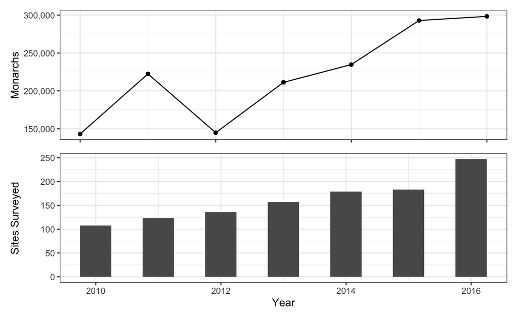

# Handedness in parrots

In 1938, Herbert Friedman and Malcom Davis wondered if parrots tended to be right or left “handed”. That is, do they tend to prefer using their right or left foot to manipulate food. They gave parrots apple slices and noted which foot they used to pick them up. Each bird was tested 20 times.

[output not shown]

| name | left | right |
| --- | --- | --- |
| Charlie | 14 | 6 |
| Lara | 13 | 7 |
| Polly | 12 | 8 |

*parrots and data are real, names were changed to protect the innocent.

1. If parrots don’t have a preference for which foot they use, then the probability of using their left foot should be 0.5. For Charlie, calculate the probability of him using his left foot 14 out of 20 times, given no preference. Repeat this for each parrot using the number of times they each used their left foot.

| name | left | right | logprob | prob |
| --- | --- | --- | --- | --- |
| Charlie | 14 | 6 | -3.297800 | 0.03696442 |
| Lara | 13 | 7 | -2.604652 | 0.07392883 |
| Polly | 12 | 8 | -2.119145 | 0.12013435 |

2. Given a model of no preference (p = 0.5), calculate a likelihood for the entire dataset.

```
[1] 0.0003282955
```

3. Calculate the MLE probability of using the left foot for the entire dataset. Repeat your likelihood calculations for this model (p = MLE p).

```
[1] 0.65
[1] 0.005094652
```

4. Use Bayes’ theorem to calculate the probability of each model, given the data, assuming that these are the only two models and using uninformative priors.

```
[1] 0.06053821
[1] 0.9394618
```

5. In 2011, Brown and Magat published a study on 322 parrots in *Biology Letters* where 47% of the parrots were left-handed. Use this information to inform prior probabilities for the 1938 data set. That is, set the prior probability for the second model (p = MLE p) to 0.47. Again, assume that “left-handed” (p = MLE p) and “no preference” (p = 0.5) are the only possible models (We’re ignoring the possibility of right-handed parrots for the sake of simplicity!). Re-calculate the probability of each model, given the 1938 data, using these informative priors.

```
[1] 0.06774295
[1] 0.932257
```